# DSC607: Intro to Data Mining

Project Supplemental Material

Joshua Chu

10/23/2020

## R Markdown

R Markdown was used to author this HTML document using a dataset obtain from baseball savant (MLB, 2020).

## Project Description

Major League Baseball pitchers can manipulate the movement of a ball by increasing or decreasing the spin rate of a baseball (Nagami, 2013). There are three forces that influence ball movement: drag force due to air movement, gravity, and the Magnus force, which the produces vertical and lateral ball movement (Nagami, 2013). Since on any given day a pitcher has no control on how the gravity impacts or influences ball movement, manipulating the spin rate of a baseball can directly increase or decrease Magnus force.

Evaluating the spin rates of different pitch types for Major League Baseball pitchers may reveal novel relationships between spin rates and resulting metrics such as total number of strikeouts, earned runs allowed, strikeout percentage, and more. The following analysis will examine the spin rates of baseballs and the relationship with strikeout percentage.

## Required Packages

The following packages are required for data manipulation (dplyr), constructing the required visuals (ggplot2, cowplot, corrplot), and modeling the data using a Bayesian Network model (e1071, factoextra, tidyverse, caret).

```r
# load the required libraries for project
library(dplyr); library(ggplot2); library(cowplot); library(corrplot);
library(ggpubr); library(factoextra); library(e1071); library(tidyverse);
library(caret)
```

## Data Loading and Summary

The dataset was obtained from Baseball Savant, which is a website that provides standard and advance baseball statistics accumulated since 1950 and 2015, respectively (Savant, 2020).

```r
# remove variables saved in environment
rm(list = ls())

# load dataset and rename columns
x <- read.csv("stats.csv")

# summary statistics for the dataset
summary(x)
```

```
##   last_name          first_name             year        player_age
##  Length:767         Length:767         Min.   :2019   Min.   :19.00
##  Class :character   Class :character   1st Qu.:2019   1st Qu.:26.00
##  Mode  :character   Mode  :character   Median :2019   Median :28.00
##                                        Mean   :2019   Mean   :28.33
##                                        3rd Qu.:2019   3rd Qu.:31.00
##                                        Max.   :2019   Max.   :42.00
##
##      p_game      p_formatted_ip    p_total_hits       p_single
##  Min.   : 1.00   Min.   :  1.00   Min.   :  1.00   Min.   :  0.00
##  1st Qu.:10.00   1st Qu.: 16.60   1st Qu.: 18.00   1st Qu.: 10.00
##  Median :25.00   Median : 41.20   Median : 40.00   Median : 24.00
##  Mean   :27.83   Mean   : 56.28   Mean   : 54.68   Mean   : 33.76
##  3rd Qu.:37.50   3rd Qu.: 72.00   3rd Qu.: 71.00   3rd Qu.: 43.00
##  Max.   :83.00   Max.   :223.00   Max.   :227.00   Max.   :151.00
##
##     p_double       p_triple        p_home_run      p_strikeout
##  Min.   : 0.0   Min.   : 0.000   Min.   : 0.000   Min.   :  0.00
##  1st Qu.: 3.0   1st Qu.: 0.000   1st Qu.: 3.000   1st Qu.: 16.00
##  Median : 8.0   Median : 1.000   Median : 6.000   Median : 40.00
##  Mean   :11.1   Mean   : 1.022   Mean   : 8.799   Mean   : 55.79
##  3rd Qu.:15.0   3rd Qu.: 1.000   3rd Qu.:12.000   3rd Qu.: 78.00
##  Max.   :50.0   Max.   :10.000   Max.   :41.000   Max.   :326.00
##
##      p_walk       p_k_percent     p_bb_percent     batting_avg
##  Min.   : 0.00   Min.   : 0.00   Min.   : 0.000   Min.   :0.0940
##  1st Qu.: 8.00   1st Qu.:17.60   1st Qu.: 6.900   1st Qu.:0.2275
##  Median :17.00   Median :21.60   Median : 9.100   Median :0.2570
##  Mean   :20.66   Mean   :21.88   Mean   : 9.904   Mean   :0.2612
##  3rd Qu.:29.00   3rd Qu.:26.10   3rd Qu.:12.000   3rd Qu.:0.2900
##  Max.   :86.00   Max.   :47.80   Max.   :35.300   Max.   :0.6250
##
##   slg_percent     on_base_percent  on_base_plus_slg     p_win
##  Min.   :0.0940   Min.   :0.1110   Min.   :0.2150   Min.   : 0.000
##  1st Qu.:0.3810   1st Qu.:0.3010   1st Qu.:0.6900   1st Qu.: 0.000
##  Median :0.4410   Median :0.3330   Median :0.7770   Median : 2.000
##  Mean   :0.4584   Mean   :0.3404   Mean   :0.7988   Mean   : 3.167
##  3rd Qu.:0.5175   3rd Qu.:0.3730   3rd Qu.:0.8820   3rd Qu.: 4.000
##  Max.   :1.3750   Max.   :0.7000   Max.   :1.9200   Max.   :21.000
##
```

[output cut: 17 more lines]

```
##  Min.   : 0.00    Min.   :67.60   Min.   :1169   Min.   : 23.00
##  1st Qu.: 7.40    1st Qu.:76.80   1st Qu.:2298   1st Qu.: 50.62
##  Median :13.30    Median :79.20   Median :2489   Median : 57.50
##  Mean   :15.33    Mean   :78.87   Mean   :2490   Mean   : 58.82
##  3rd Qu.:21.43    3rd Qu.:81.20   3rd Qu.:2666   3rd Qu.: 66.38
##  Max.   :60.20    Max.   :87.20   Max.   :3431   Max.   :100.00
##  NA's   :315      NA's   :315     NA's   :316    NA's   :61
##  fastball_avg_speed fastball_avg_spin    X
##  Min.   : 82.40     Min.   :1820      Mode:logical
##  1st Qu.: 91.20     1st Qu.:2151      NA's:767
##  Median : 92.90     Median :2254
##  Mean   : 92.84     Mean   :2259
##  3rd Qu.: 94.60     3rd Qu.:2374
##  Max.   :101.10     Max.   :2889
##  NA's   :61         NA's   :61
```

The data is comprised of 767 observations and 36 variables for Major League Baseball pitchers for the year 2019 (Savant, 2020). Below shows the features of interest for this investigation. There are multiple missing values for the four pitch types and will need to be resolved.

```
 1. p_k_percent: strikeout percentage
 2. sl_avg_spin: average slider spin rate (revolutions per minute)
 3. ch_avg_spin: average changeup spin rate (revolutions per minute)
 4. cu_avg_spin: average curveball spin rate (revolutions per minute)
 5. fastball_avg_spin: average fastball spin rate (revolutions per minute)
```

## Exploratory Data Analysis

A correlation plot was used to examine the relationship between the pitch types and strikeout percentage, as well as additional features that may reveal novel relationships.

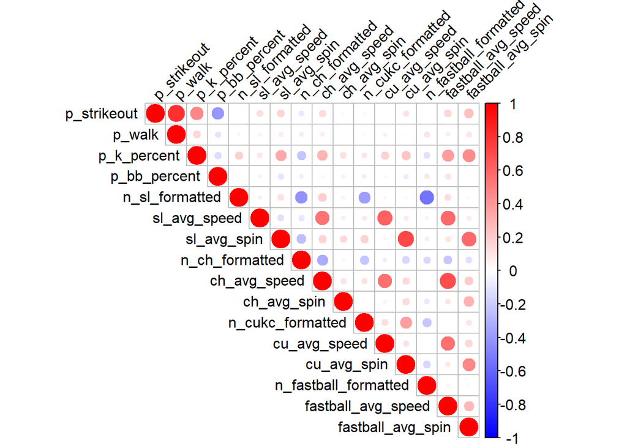

```r
# subset numerical data from categorical
y <- x[,c(12:19,22:35)]

# correlation table
corrplot(cor(y[,c(1:4,11:22)],use = "complete.obs"), type = "upper",
         tl.col = "black",tl.srt = 45, tl.cex = 1, cl.cex = 1,
         col=colorRampPalette(c("blue","white","red"))(200))
```

A positive relationship exists between the spin rates and the total number of strikeouts and strikeout percentage. While interesting, the percent strikeout metric is more valuable because the frequency includes the total number of batters a pitcher faces throughout the season (Sawchik, 2018). For instance, a strikeout total of 138 may not seem impressive since many pitchers accumulate over 150 strikeouts for an entire season. However, examining the strikeout percentage for the same player, which is 47.8% and the best mark in MLB for 2019, we see this pitcher is highly efficient since his strikeout percentage is a much higher frequency than the MLB average (22%; summary stats shown above). Therefore, the strikeout percentage and four pitch types will be utilized for further investigation. To confirm a linear relationship, a linear regression between the strikeout percentage and pitch types were performed.

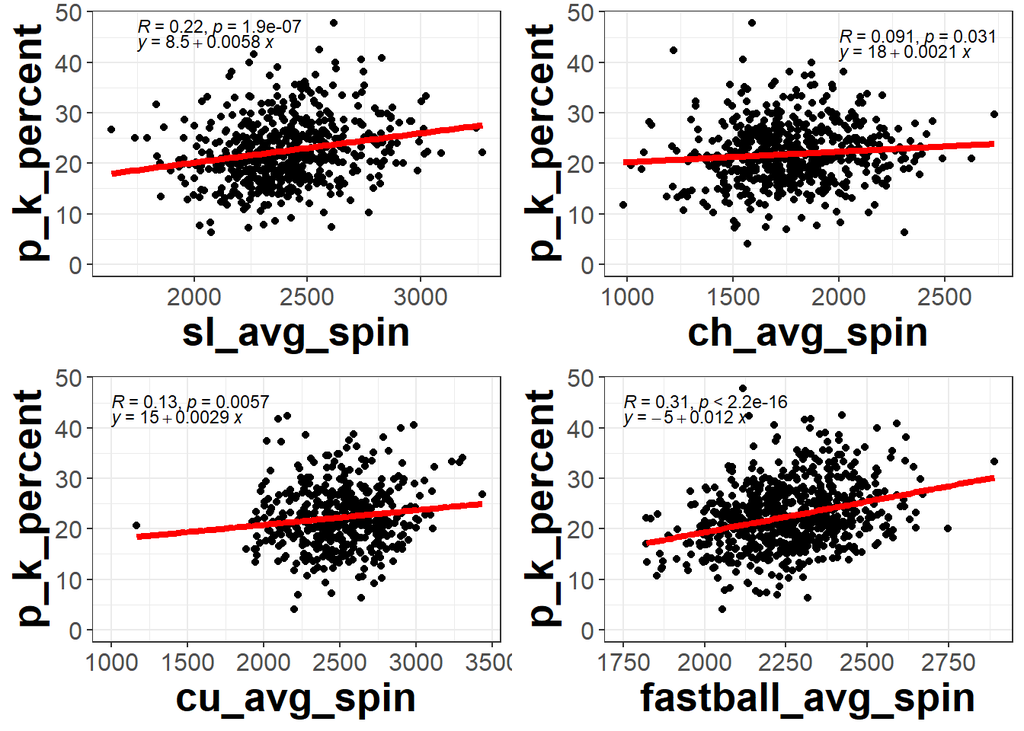

```r
# linear regressions to confirm relationship between strikeout percentage
# and the four different pitch types
a <- ggplot(y,aes(sl_avg_spin,p_k_percent))+geom_point(na.rm = TRUE) +
        stat_smooth(method = "lm", se = FALSE, na.rm = TRUE, color = "red", size = 1.5) +
        stat_cor(label.x = 1750, label.y = 47, na.rm = TRUE, size = 3) +
        stat_regline_equation(label.x = 1750, label.y = 44, na.rm = TRUE, size = 3) +
        theme_bw()+theme(axis.title = element_text(face = "bold",size = 20),
                         axis.text = element_text(size = 12))

b <- ggplot(y,aes(ch_avg_spin,p_k_percent))+geom_point(na.rm = TRUE) +
        stat_smooth(method = "lm", se = FALSE, na.rm = TRUE, color = "red", size = 1.5) +
        stat_cor(label.x = 2000, label.y = 45, na.rm = TRUE, size = 3) +
        stat_regline_equation(label.x = 2000, label.y = 42, na.rm = TRUE, size = 3) +
        theme_bw()+theme(axis.title = element_text(face = "bold",size = 20),
                         axis.text = element_text(size = 12))

c <- ggplot(y,aes(cu_avg_spin,p_k_percent))+geom_point(na.rm = TRUE) +
        stat_smooth(method = "lm", se = FALSE, na.rm = TRUE, color = "red", size = 1.5) +
        stat_cor(label.x = 1000, label.y = 45, na.rm = TRUE, size = 3) +
        stat_regline_equation(label.x = 1000, label.y = 42, na.rm = TRUE, size = 3) +
        theme_bw()+theme(axis.title = element_text(face = "bold",size = 20),
                         axis.text = element_text(size = 12))

d <- ggplot(y,aes(fastball_avg_spin,p_k_percent))+geom_point(na.rm = TRUE) +
        stat_smooth(method = "lm", se = FALSE, na.rm = TRUE, color = "red", size = 1.5) +
        stat_cor(label.x = 1750, label.y = 45, na.rm = TRUE, size = 3) +
        stat_regline_equation(label.x = 1750, label.y = 42, na.rm = TRUE, size = 3) +
        theme_bw()+theme(axis.title = element_text(face = "bold",size = 20),
                         axis.text = element_text(size = 12))

plot_grid(a,b,c,d)
```

According to the regression analysis, all regression models were statistically significant with a p value < 0.05. The coefficient of determination varies among the models, with fastballs performing the best and the changeup performing the worst among all pitch types. Now that I confirmed a relationship exists, we can move on to using the dataset to categorize pitchers according to this relationship.

```r
# subset dataset by pitch spin rates
df  <- x[,c(14,26,29,32,35)]

# summary statistics for the dataset
summary(df)
```

```
##   p_k_percent     sl_avg_spin    ch_avg_spin    cu_avg_spin   fastball_avg_spin
##  Min.   : 0.00   Min.   :1634   Min.   : 979   Min.   :1169   Min.   :1820
##  1st Qu.:17.60   1st Qu.:2245   1st Qu.:1592   1st Qu.:2298   1st Qu.:2151
##  Median :21.60   Median :2381   Median :1759   Median :2489   Median :2254
##  Mean   :21.88   Mean   :2401   Mean   :1774   Mean   :2490   Mean   :2259
##  3rd Qu.:26.10   3rd Qu.:2537   3rd Qu.:1943   3rd Qu.:2666   3rd Qu.:2374
##  Max.   :47.80   Max.   :3270   Max.   :2732   Max.   :3431   Max.   :2889
##                  NA's   :217    NA's   :207    NA's   :316    NA's   :61
```

The original dataset was further partitioned to only include the strikeout percentage and spin rates for the aforementioned pitch types. Spin rates are of particular interest to pitchers because the ‘movement’ of a ball can be altered by different spin rates, which in turn could impact a batters perception for the balls trajectory, inducing more swing and misses, and generating a large strikeout percentage (Nagami, 2013).

Again, examining the summary statistics reveals missing values are still prevalent for most features in the dataset with the strikeout percentage variable being the exception. Changeups, on average, possess the lowest spin rates for all pitch types, and the curveball and slider have the fastest. The minimum value for the changeup is much smaller than the other pitch types. In all cases, the median and mean do not differ by much, indicating there are few to no outliers present in the dataset.

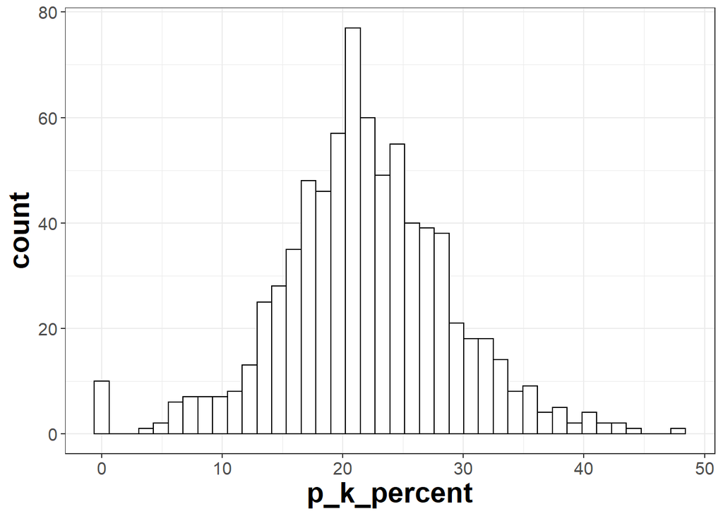

```r
# histogram for strikeout percentage
ggplot(df,aes(p_k_percent)) + geom_histogram(color="black", fill="white", bins = 40,na.rm = TRUE) +
        theme_bw()+theme(axis.title = element_text(face = "bold",size = 20),
                         axis.text = element_text(size = 12))
```

The strikeout percentage attribute has a normal distribution, with an odd frequency at the zero marker. This likely indicates there are multiple picthers with a zero strikeout percentage. Because this feature is normally distributed, no other manipulations to this variable will be performed. Since the data are normally distributed, I could use the quartiles identified in the summary stats to assign pitchers to categories, but this will be investigated later.

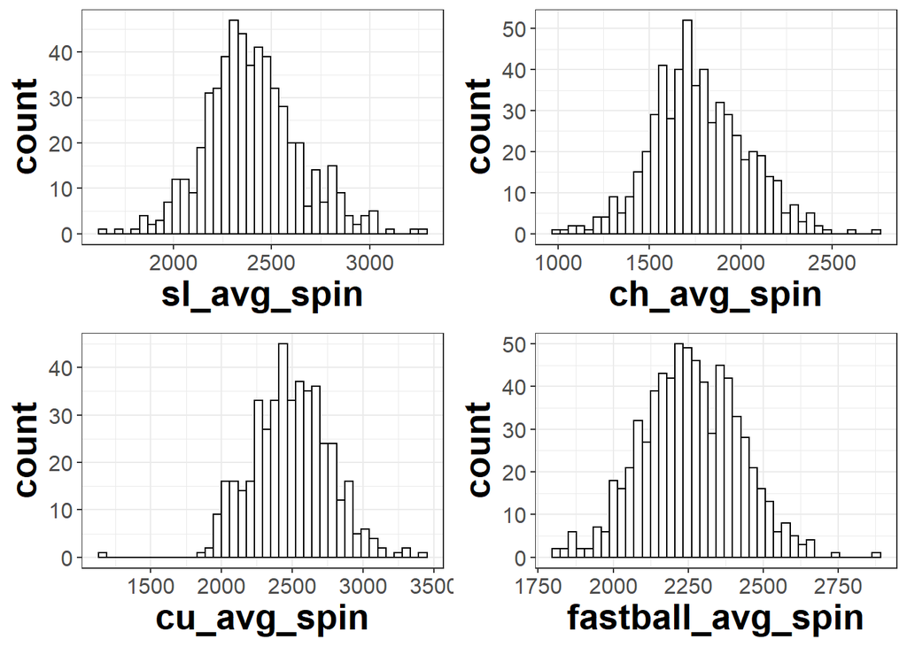

```r
# examine spin rates for pitches
q <- ggplot(df,aes(sl_avg_spin))+geom_histogram(color="black", fill="white", bins = 40, na.rm = TRUE) +
        theme_bw()+theme(axis.title = element_text(face = "bold",size = 20),
                         axis.text = element_text(size = 12))

r <- ggplot(df,aes(ch_avg_spin))+geom_histogram(color="black", fill="white", bins = 40, na.rm = TRUE) +
        theme_bw()+theme(axis.title = element_text(face = "bold",size = 20),
                         axis.text = element_text(size = 12))

s <- ggplot(df,aes(cu_avg_spin))+geom_histogram(color="black", fill="white", bins = 40, na.rm = TRUE) +
        theme_bw()+theme(axis.title = element_text(face = "bold",size = 20),
                         axis.text = element_text(size = 12))

t <- ggplot(df,aes(fastball_avg_spin))+geom_histogram(color="black", fill="white", bins = 40, na.rm = TRUE) +
        theme_bw()+theme(axis.title = element_text(face = "bold",size = 20),
                         axis.text = element_text(size = 12))

plot_grid(q,r,s,t)
```

Surprisingly, the spin rates for all four pitch types are normally distributed. Consistent with the summary statistics, the changeup has the smallest mean compared to the other three pitch types. Visually, the fastball feature appears to have more data points than the other, however, replacing the NA values with the mean of each pitch type should resolve any feature size bias.

## Determine the Number of Pitcher Categories Using Cluster Analysis

```r
# eliminate NAs from dataset and replace with 0
df[is.na(df)] <- 0

# convert to dataframe
df  <- data.frame(df)

# scale data
df <- scale(df)
```

As noted earlier, NAs were discovered in the dataset and needed to be removed prior to the analysis. All missing values were converted to 0 and the dataset was formatted to a data frame, followed by scaling the data to make the variables comparable.

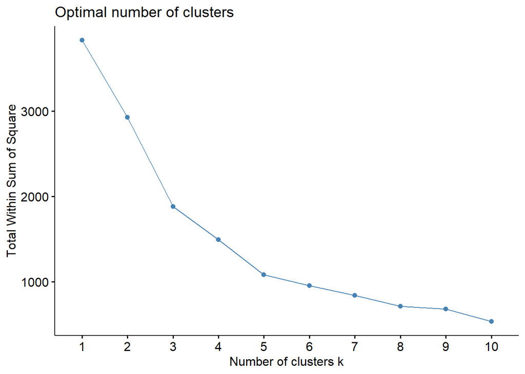

```r
# determine the number of clusters using the elbow method
fviz_nbclust(df, kmeans, method = "wss")
```

The above plot was utilized to identify the optimal number of clusters needed to perform the K means cluster analysis. df is the data frame the function will use to determine the number of clusters; kmeans is a partitioning arguement indicating the cluster method; and the final variable is the method used to estimate the optimal number of clusters. Using the elbow method, the optimal number of clusters was determined to be 5 (Guide, 2020).

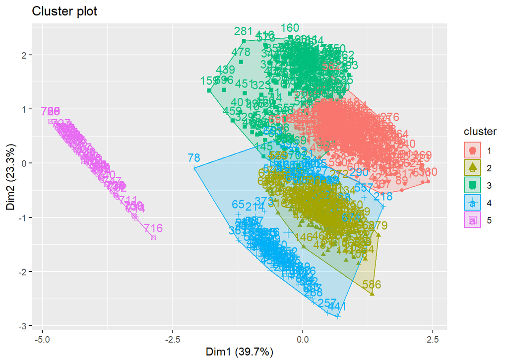

```r
# cluster analysis
k <- kmeans(df, centers = 5, nstart = 25)
fviz_cluster(k, data = df)
```

kmeans was the function utilized to construct the cluster plot: df is the data frame, the number of centers was determine to be 5 (previous step), and the nstart indicates the number of random sets that should be attempted and reports on the ‘best’ clustering configuration (Guide, 2020).

```r
# examine the last 6 rows of the original dataset
tail(x[,c(14,26,29,32,35)])
```

```
##     p_k_percent sl_avg_spin ch_avg_spin cu_avg_spin fastball_avg_spin
## 762        28.6          NA          NA          NA                NA
## 763         9.1          NA          NA          NA                NA
## 764        10.0          NA          NA          NA                NA
## 765        11.1          NA          NA          NA                NA
## 766         5.9          NA          NA          NA                NA
## 767        21.1          NA          NA          NA                NA
```

Originally, I thought the dataset had random NAs throughout the features, not necessarily consecutive records having NAs. Now that these have been identified, the pitchers that did not contain usable data were removed (records 707 through 767) and the additional missing values will be replaced with the average values for their respective features (shown below). The cluster analysis was repeated using a center number of four instead of five.

```r
# subset dataset by pitch spin rates
df  <- x[1:706,c(14,26,29,32,35)]

# replace NAs with average of each feature
df$sl_avg_spin[is.na(df$sl_avg_spin)] <- 2401
df$ch_avg_spin[is.na(df$ch_avg_spin)] <- 1774
df$cu_avg_spin[is.na(df$cu_avg_spin)] <- 2490
df$fastball_avg_spin[is.na(df$fastball_avg_spin)] <- 2259

# convert to dataframe
df  <- data.frame(df)

# scale data
df1 <- scale(df)
```

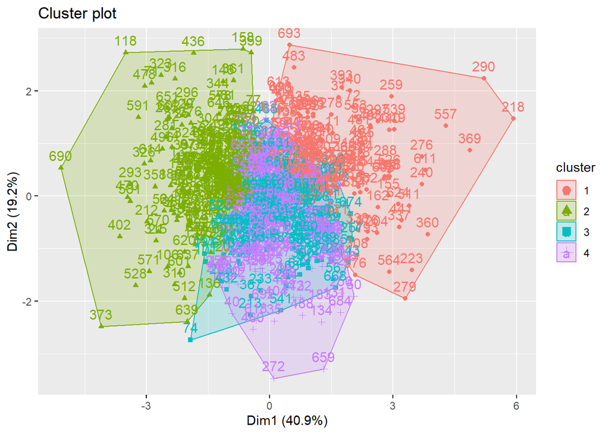

```r
# cluster analysis
k1 <- kmeans(df1, centers = 4, nstart = 25)
fviz_cluster(k1, data = df1)
```

While the presumed outliers have shifted toward the other data points, there remains considerable overlap between all clusters. The poor separation suggests the Bayesian Network model may produce poor results when attempting to catagorize pitchers. The next two plots lowered the number of centers to try and reduce the overlap between clusters.

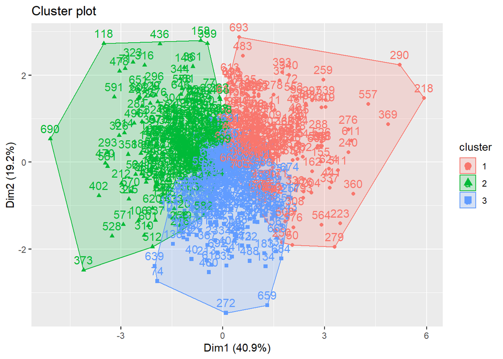

```r
# cluster analysis
k1 <- kmeans(df1, centers = 3, nstart = 25)
fviz_cluster(k1, data = df1)
```

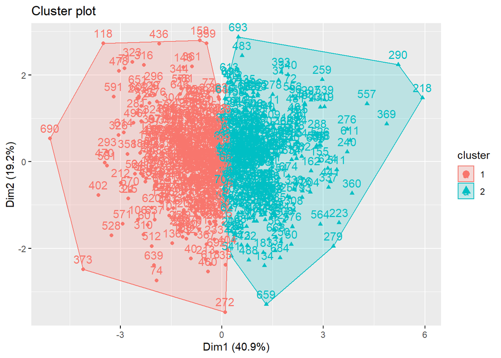

```r
# cluster analysis
k1 <- kmeans(df1, centers = 2, nstart = 25)
fviz_cluster(k1, data = df1)
```

Reducing the number of centers progressively improved the clustering of the data points. While the majority of the data points are located near the center of the plot, there is a better separation between the clusters than previously seen. To try and completely separate the clusters, the cmeans function was used to resolve the ‘fuzzy’ nature of the current cluster results (Tan, 2018).

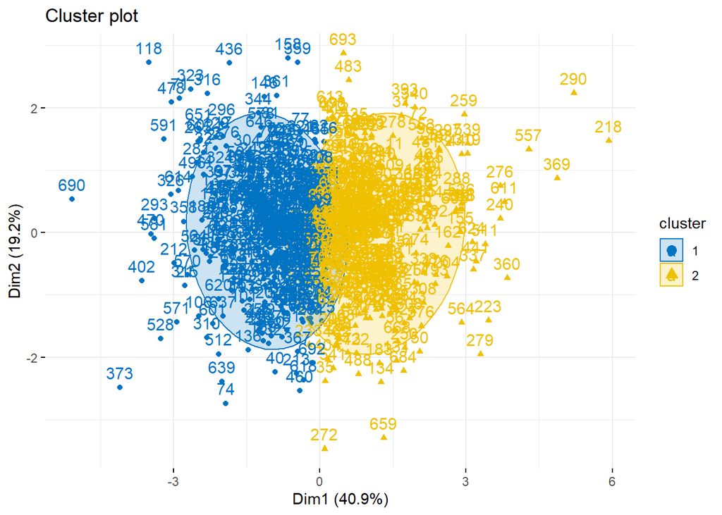

```r
# use cmeans to resolve the overlap between clusters 1 and 2
k2 <- cmeans(df1, centers = 2)
fviz_cluster(list(data = df1, cluster=k2$cluster),
             ellipse.type = "norm",
             ellipse.level = 0.85,
             palette = "jco",
             ggtheme = theme_minimal())
```

Using the same number of clusters as before (i.e. k = 2), the cmeans function was used as an alternative function to resolve the overlap between clusters 1 and 2. Additional parameters were used in the cmeans function, however, these parameters failed to improve the results and were eliminated for simplicity.

The function fviz_cluster was used to visualize the plot using a list object as the cluster components. The data to be plotted is found in df1, and the clusters each data point is assigned to is given by the cluster arguement. The next two arguements places ellipses around the data points that belong to each cluster, while enclosing only 85% of the data points. Finally, the last two arguements are for visualization purposes only.

Visually comparing this plot with the previous plot (where k = 2), there does not appear to be any differences or improvements in separating the two clusters. Overall, the results suggest I should use 2 pitching catagories (e.g. below average and above average) to assign pitchers. Increasing the number of assignments will likely reduce the accuracy of the model.

## Prepare Data for Bayesian Network Modeling

Missing values have been addressed and the number of pitching assignments have been determined. Now that I know the required structure of the dataset, I need to prepare the data for analysis. The first step is to construct a single pitch column, which would combine all of pitch types into a single feature.

```r
# convert to dataframe
df2  <- data.frame(df)

# prepare dataset for analysis
c  <- df2[,1:2]
c1 <- df2[,c(1,3)]
c2 <- df2[,c(1,4)]
c3 <- df2[,c(1,5)]

c<-mutate(c,"spin_slider")
colnames(c) <- c("percent_strikeouts", "spin_rate", "pitch")
c1<-mutate(c1,"spin_changeup")
colnames(c1) <- c("percent_strikeouts", "spin_rate", "pitch")
c2<-mutate(c2,"spin_curve")
colnames(c2) <- c("percent_strikeouts", "spin_rate", "pitch")
c3<-mutate(c3,"spin_fastball")
colnames(c3) <- c("percent_strikeouts", "spin_rate", "pitch")
e<-rbind(c,c1,c2,c3)
```

The next step is to construct a new column to assign pitching effectiveness. This new feature will be called pitch_assignment and will be given a below average or above average designation based on being below or above the strikeout percentage for the particular record. Following this assignment, the strikeout percentage was removed from the data frame prior to analysis, and all variables were converted to factors, a necessary transformation when constructing a Bayesian Network model in R.

```r
# assign each pitch to a category; categories were determined using the percent
# strikeout quartiles
e <- mutate(e,pitch_assignment = 0)
e$pitch_assignment[e$percent_strikeouts <= mean(e$percent_strikeouts)] <- "Below_avg"
e$pitch_assignment[e$percent_strikeouts > mean(e$percent_strikeouts)] <- "Above_avg"

# construct final dataset
sub_e <- e[,c(2:4)]
final_e <- sub_e
final_e$spin_rate <- as.factor(final_e$spin_rate)
final_e$pitch <- as.factor(final_e$pitch)
final_e$pitch_assignment <- as.factor(final_e$pitch_assignment)
```

A training and testing set was constructed for the model. Using the createDataPartition function splits the data into a 85% training and 15% testing set. Once the two sets were made, basic statistics were recorded for both sets of data.

```r
# the createDataPartition does a stratified random split dividing the data into
# 85% training and 15% testing
trn <- createDataPartition(y = final_e$pitch_assignment, p = 0.85, list = FALSE)
training <- final_e[trn,]
test <- final_e[-trn,]

# determine the number of records for each dataset
c(Training=nrow(training),Test=nrow(test))
```

```
## Training     Test
##     2401      423
```

```r
# find the number of records for each pitching assignment
c(Training=table(training$pitch_assignment),Test=table(test$pitch_assignment))
```

```
## Training.Above_avg Training.Below_avg     Test.Above_avg     Test.Below_avg
##               1088               1313                192                231
```

```r
# find the percentage of records for each dataset
c(Training=prop.table(table(training$pitch_assignment)),Test=prop.table(table(test$pitch_assignment)))
```

```
## Training.Above_avg Training.Below_avg     Test.Above_avg     Test.Below_avg
##          0.4531445          0.5468555          0.4539007          0.5460993
```

The training and test set contains 2401 and 423 records, respectively, consistent with an 85% and 15% split. By the numbers, the below average category is more abundant for the training and testing dataset. Examining the distributions between the two datasets for each category, the percentages do not vary, indicating there is not an extreme bias towards one category between the two datasets. This is important because if the training set would flip the frequencies for each category, model predictions may be inaccurate due to inconsistencies between the datasets.

## Perform Bayesian Network Modeling

```r
# train the model
Naive_Bayes_Model <- naiveBayes(pitch_assignment ~., data=training)


# predicitons
NB_Predictions <- predict(Naive_Bayes_Model,test)
table(NB_Predictions,test$pitch_assignment)
```

```
##
## NB_Predictions Above_avg Below_avg
##      Above_avg        85        88
##      Below_avg       107       143
```

## References

Advanced Media, MLB. (2020). Retrieved from https://baseballsavant.mlb.com/leaderboard/custom?year=2019&type=pitcher&filter=&sort=4&sortDir=asc&min=q&selections=xba,xslg,xwoba,xobp,xiso,exit_velocity_avg,launch_angle_avg,barrel_batted_rate,&chart=false&x=xba&y=xba&r=no&chartType=beeswarm. Date Accessed: Sept 27, 2020.

UC Business Analytics R Programming Guide. (2020). K-means Cluster Analysis. Retrieved from https://uc-r.github.io/kmeans_clustering. Accessed Date: Oct 15, 2020.

Nagami, T., Higuchi, T., & Kanosue, K. (2013). How baseball spin influences the performance of a pitcher. The Journal of Physical Fitness and Sports Medicine, 2(1), 63-68. doi:10.7600/jpfsm.2.63

Savant. (2020). Statcast Leaderboards. Retrieved from https://baseballsavant.mlb.com/leaderboard/custom?year=2019&type=pitcher&filter=&sort=4&sortDir=asc&min=q&selections=xba,xslg,xwoba,xobp,xiso,exit_velocity_avg,launch_angle_avg,barrel_batted_rate,&chart=false&x=xba&y=xba&r=no&chartType=beeswarm. Accessed Date: September 20, 2020.

Sawchik, T. (2018). Baseball’s Top Staffs Have Come Around On The High-Spin Fastball. Retrieved from https://fivethirtyeight.com/features/baseballs-top-staffs-have-come-around-on-the-high-spin-fastball/. Accessed Date: Sept 28, 2020.

Tan, P.-N., Steinbach, M., Karpatne, A., & Kumar, V. (2018). Introduction to Data Mining: Pearson; 2nd Edition.